# DS4-EDA Course Project

### Preparing Data

```r
URL <- "https://d396qusza40orc.cloudfront.net/exdata%2Fdata%2FNEI_data.zip"

if (!file.exists("./tmp")) dir.create("./tmp")
if (!file.exists("./pm25_data")) dir.create("./pm25_data")

if (!file.exists("./tmp/pm25data.zip")){
        download.file(
        URL, destfile = "./tmp/pm25data.zip"
        )
} else {
        unzip("./tmp/pm25data.zip", exdir = "./pm25_data", overwrite = FALSE)
}
dir("./pm25_data/")
```

```
## [1] "Source_Classification_Code.rds" "summarySCC_PM25.rds"
```

Each of the two files can be read using the 𝚛𝚎𝚊𝚍𝚁𝙳𝚂() function in R.

```r
NEI <- readRDS("./pm25_data/summarySCC_PM25.rds")
SCC <- readRDS("./pm25_data/Source_Classification_Code.rds")

dim(NEI)
```

```
## [1] 6497651       6
```

```r
head(NEI)
```

```
##     fips      SCC Pollutant Emissions  type year
## 4  09001 10100401  PM25-PRI    15.714 POINT 1999
## 8  09001 10100404  PM25-PRI   234.178 POINT 1999
## 12 09001 10100501  PM25-PRI     0.128 POINT 1999
## 16 09001 10200401  PM25-PRI     2.036 POINT 1999
## 20 09001 10200504  PM25-PRI     0.388 POINT 1999
## 24 09001 10200602  PM25-PRI     1.490 POINT 1999
```

```r
dim(SCC)
```

```
## [1] 11717    15
```

```r
head(SCC)
```

```
##        SCC Data.Category
## 1 10100101         Point
## 2 10100102         Point
## 3 10100201         Point
## 4 10100202         Point
## 5 10100203         Point
## 6 10100204         Point
##                                                                   Short.Name
## 1                   Ext Comb /Electric Gen /Anthracite Coal /Pulverized Coal
## 2 Ext Comb /Electric Gen /Anthracite Coal /Traveling Grate (Overfeed) Stoker
## 3       Ext Comb /Electric Gen /Bituminous Coal /Pulverized Coal: Wet Bottom
## 4       Ext Comb /Electric Gen /Bituminous Coal /Pulverized Coal: Dry Bottom
## 5                   Ext Comb /Electric Gen /Bituminous Coal /Cyclone Furnace
## 6                   Ext Comb /Electric Gen /Bituminous Coal /Spreader Stoker
##                                EI.Sector Option.Group Option.Set
```

[output cut: 34 more lines]

### 1. Have total emissions from PM2.5 decreased in the United States from 1999 to 2008? Using the base plotting system, make a plot showing the total PM2.5 emission from all sources for each of the years 1999, 2002, 2005, and 2008.

```r
totalEmissions <- with(NEI, tapply(Emissions/1000,year,sum,na.rm=TRUE))
```

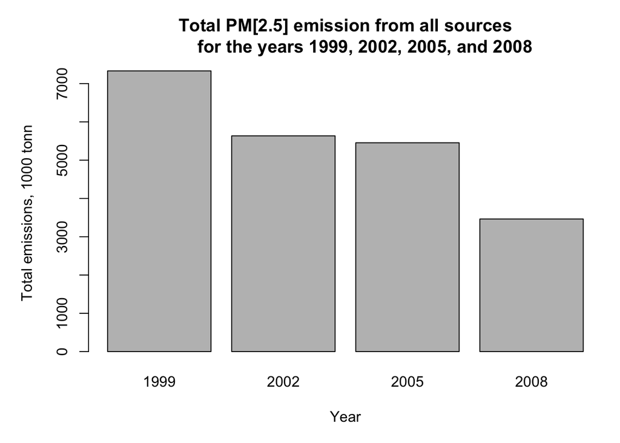

There is a clear downward trend in total emissions from PM2.5 in US in the years 1999, 2002, 2005, and 2008.

### 2. Have total emissions from PM2.5 decreased in the Baltimore City, Maryland (𝚏𝚒𝚙𝚜 == “𝟸𝟺𝟻𝟷𝟶”) from 1999 to 2008? Use the base plotting system to make a plot answering this question.

```r
baltimoreEmissions <- NEI[NEI$fips == "24510",]
baltimoreTotalEmissions <- with(baltimoreEmissions, tapply(Emissions,year,sum,na.rm=TRUE))
```

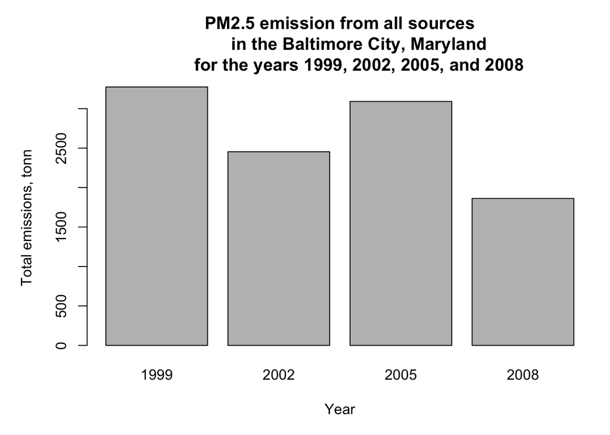

### 3. Of the four types of sources indicated by the 𝚝𝚢𝚙𝚎 (point, nonpoint, onroad, nonroad) variable, which of these four sources have seen decreases in emissions from 1999–2008 for Baltimore City? Which have seen increases in emissions from 1999–2008? Use the ggplot2 plotting system to make a plot answer this question.

```r
baltimoreEmissions <- NEI[NEI$fips == "24510",]
baltimoreEmissionsBySource <-
        aggregate(
                baltimoreEmissions[c("Emissions")],
                list(Source = baltimoreEmissions$type,
                     Year = baltimoreEmissions$year),
                sum
        )
```

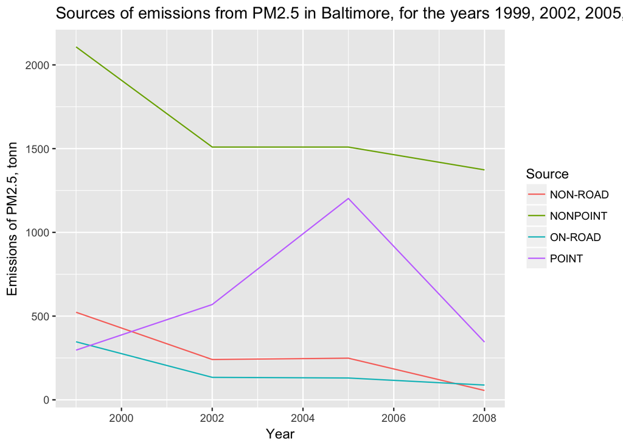

Emissions for three of four source types (NON-ROAD, NONPOINT and ON-ROAD) have decreased in the end of the period (year 2008) compared to its beginning (year 1999). Also it can be seen that the most part of decrease occurred in the period from 1999 to 2002 for the same three sources. Source type POINT shown strong increase during the years 1999-2005, changed to sharp fall ended in 2008 almost on the same level as it showed in 1999.

### 4. Across the United States, how have emissions from coal combustion-related sources changed from 1999–2008?

```r
coalSources <- SCC[grep("coal",SCC$EI.Sector,ignore.case = TRUE),c("SCC","Short.Name")]
coalEmissions <- NEI[NEI$SCC %in% coalSources$SCC,]
coalTortalEmissions <- with(coalEmissions, tapply(Emissions/1000,year,sum,na.rm=TRUE))
```

[figure not shown]

Coal combustion-related emissions decreased by half by 2008 compared to 1999, showing a steady decline throughout the period.

### 5. How have emissions from motor vehicle sources changed from 1999–2008 in Baltimore City?

```r
motorSources <- SCC[grep("motor|vehicle",SCC$EI.Sector, ignore.case = TRUE),c("SCC","Short.Name")]
baltimoreMotorEmissions <- NEI[NEI$SCC %in% motorSources$SCC & NEI$fips == "24510",]
baltimoreToatalMotorEmissions <- with(baltimoreMotorEmissions, tapply(Emissions,year,sum,na.rm=TRUE))
```

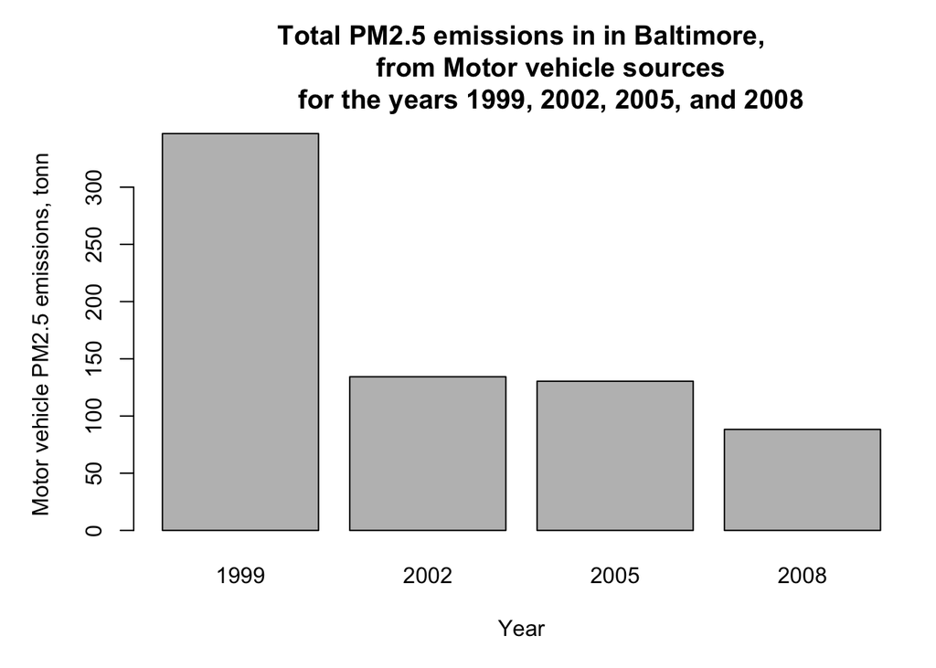

Motor vehicle emissions in Baltimore has shown a sharp decline in 2002 by about 60% compared to 1999. However, since 2002, the dynamics changed and by 2005 the levels had not changed, only in 2008 there was a significant decrease

### 6. Compare emissions from motor vehicle sources in Baltimore City with emissions from motor vehicle sources in Los Angeles County, California (𝚏𝚒𝚙𝚜 == “𝟶𝟼𝟶𝟹𝟽”). Which city has seen greater changes over time in motor vehicle emissions?

```r
losangelesMotorEmissions <-
        NEI[NEI$SCC %in% motorSources$SCC &
                    NEI$fips == "06037", ]
twocityMotorEmissions <-
        rbind (losangelesMotorEmissions, baltimoreMotorEmissions)
twocityMotorEmissionsByFips <-
        aggregate(
                twocityMotorEmissions[c("Emissions")],
                list(City = twocityMotorEmissions$fips,
                     Year = twocityMotorEmissions$year),
                sum
        )
twocityMotorEmissionsByFips$City <-
        factor(
                twocityMotorEmissionsByFips$City,
                levels = c("06037", "24510"),
                labels = c("Los Angeles, CA", "Baltimore City, MD")
        )
```

```r
summary(baltimoreMotorEmissions$Emissions)
```

```
##    Min. 1st Qu.  Median    Mean 3rd Qu.    Max.
##  0.0000  0.0024  0.0200  0.6254  0.3443 46.4300
```

```r
summary(losangelesMotorEmissions$Emissions)
```

```
##      Min.   1st Qu.    Median      Mean   3rd Qu.      Max.
##    0.0003    0.0600    0.4745   17.2529    4.7325 1643.8500
```

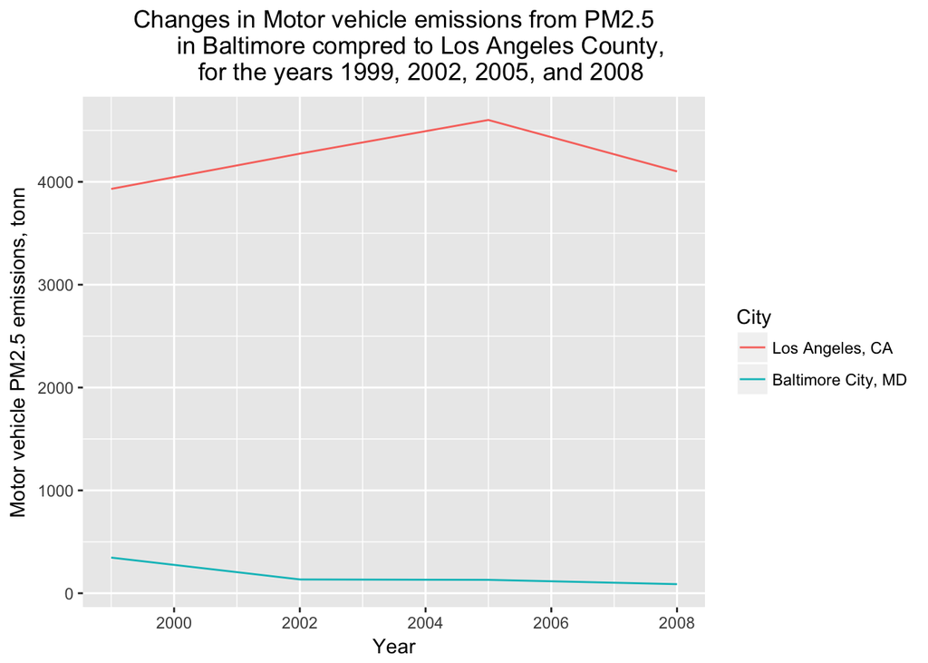

First noticeable observation is that overall motor vehicle emissions levels are significantly higher in LA compared to Baltimore. Change dynamics is also quite opposite. While PM2.5 from motor vehicles showed a steady decline in Baltimore, especially in the beginning of the period, in LA it was on the rise until 2005, then began to decline. However, even after lowering, the final level of emissions for Los Angeles in 2008 is slightly higher than it was in 1999.